title: “Solución Taller Práctico” author: “Herramientas Computacionales” date: “03 agosto, 2020” output: prettydoc::html_pretty: theme: cayman highlight: github

## Taller Práctico

Antes de partir, se importa la base de datos:

```r
library(tidyverse)
data <- readxl::read_excel("PlayStore.xlsx")
```

### Pregunta 1

Use las herramientas de dplyr para ordenar la base de datos de acuerdo a la variable `TAMAÑO`. Luego, seleccione sólo las que son de pago, y con ello genere una variable `GANANCIAS` que estima el dinero recibido por la empresa, calculado como el precio por el número de descargas aproximado (5000 aprox. = 5000) y realice un promedio de ganancias para cada categoría. Comente.

```r
data2 <- data %>%
  dplyr::arrange(`Tamaño(M)`) %>%
  dplyr::filter(Tipo == "Pago") %>%
  dplyr::mutate(Descargas = gsub("aprox.", "", Descargas),
                Descargas = gsub(",", "", Descargas),
                Ganancias = as.numeric(Descargas)*Precio)

Ganancias_Promedio <- data2 %>%
  dplyr::group_by(`Categoría`) %>%
  dplyr::summarise(Ganancias = round(mean(Ganancias, na.rm = TRUE), 0))

DT::datatable(Ganancias_Promedio)
```

|  | Categoría | Ganancias |
| --- | --- | --- |
| 1 | ARTE Y DISEÑO | 10613 |
| 2 | CLIMA | 197481 |
| 3 | COMIDA Y BEBIDA | 249500 |
| 4 | COMPRAS | 15075 |
| 5 | COMUNICACIÓN | 35021 |
| 6 | DATOS | 1712 |
| 7 | DEPORTES | 163987 |
| 8 | EDUCACIÓN | 734162 |
| 9 | ENTRETENIMIENTO | 299000 |
| 10 | ESTILO DE VIDA | 3339679 |

[output cut: 20 more lines]

> Se observan fuertes diferencias en el promedio de ganancias para cada categoría. Estos promedios varían entre 99 y 3.339.679 unidades.

### Pregunta 2

Considere nuevamente todos los tipos de adquisión. Entregue un gráfico que represente la distribución de la `VALORACIÓN` para cada categoría, y otro gráfico que represente la distribución por TIPO de adquisición (pagada o gratis). Comente.

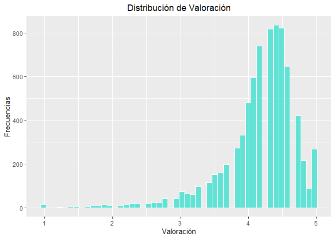

```r
ggplot(data = data, aes(x = `Valoración`)) +
  geom_histogram(bins = 50, alpha = 0.8, color = "white", fill = "turquoise") +
  xlab("Valoración") +
  ylab("Frecuencias") +
  ggtitle("Distribución de Valoración") +
  theme(plot.title = element_text(hjust = 0.5))
```

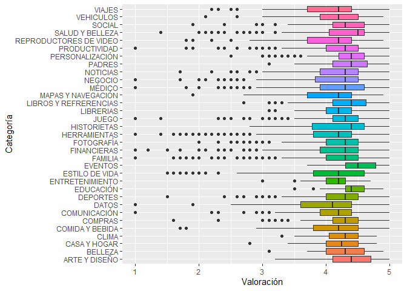

```r
ggplot(data = data, aes(x = `Categoría`, y = `Valoración`, fill = `Categoría`)) +
  geom_boxplot() +
  coord_flip()+
  theme(legend.position="none")
```

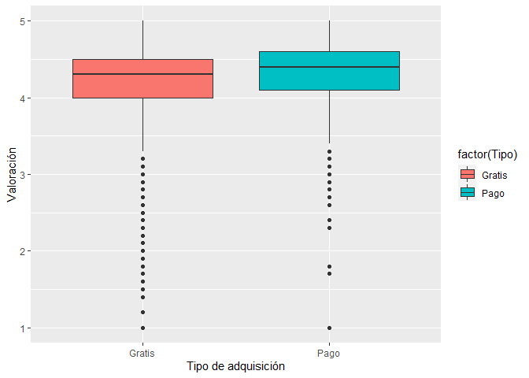

```r
ggplot(data = data, aes(y = `Valoración`, x = factor(Tipo),  fill = factor(Tipo)))+
  geom_boxplot() +
  xlab("Tipo de adquisición")
```

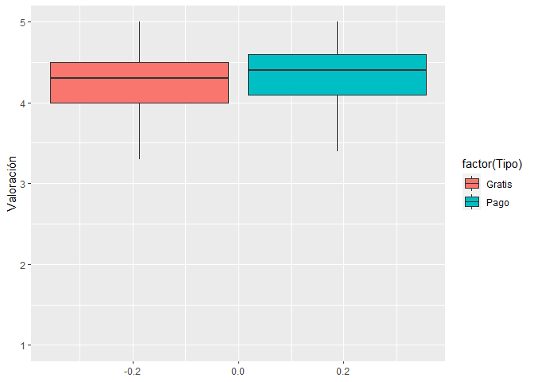

```r
### Para quitar los Outliers:
ggplot(data = data, aes(y = `Valoración`, fill = factor(Tipo))) +
  geom_boxplot(outlier.shape = NA)
```

> Se observan diferencias en la distribución de la valoración para las distintas categorías. La mayoría tiene datos atípicos correspondiente a baja valoración. La categoría más heterogénea en su valoración es DATOS, y la más homogénea es EDUCACIÓN.

> La forma de la distribución de la valoración para el tipo de aplicación es similar en pago y gratis, sin embargo, las aplicaciones pagadas, tienden a tener mayor valoración que las de no pago.

### Pregunta 3

Realice un gráfico que ilustre la `CLASIFICACIÓN` de las aplicaciones. Considere un orden correcto para las categorías. Comente.

El orden natural debiese ser:

```r
Orden <- c("Todo público", "Mayores de 10 años", "Adolescentes",
           "Mayores de 17 años", "Sólo adultos", "Sin clasificación")
```

Conla función `factor()` se ingresan los nuevos niveles de la variable.

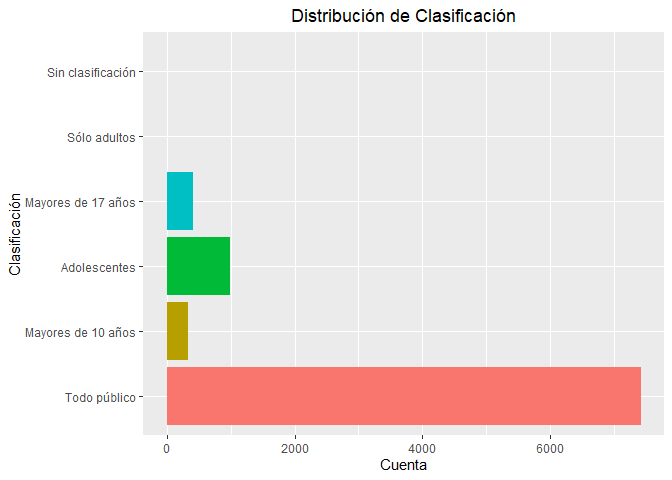

```r
data <- data %>%
  dplyr::mutate(Clasificacion2 = factor(`Clasificación`, levels = Orden))

ggplot(data, aes(x = Clasificacion2, fill = Clasificacion2)) +
  geom_bar() +
  coord_flip() +
  theme(legend.position = "none") +
  ylab("Cuenta") +
  xlab("Clasificación") +
  ggtitle("Distribución de Clasificación") +
  theme(plot.title = element_text(hjust = 0.5))
```

> La mayoría de las aplicaciones de este conjunto de datos correponde a clasificación Todo Público.

### Pregunta 4

Genere una función que, al recibir un nivel de la variable `CATEGORÍA`, reporte un gráfico sobre la `VALORACIÓN` y un resumen numérico del `TAMAÑO` para ese nivel. Pruebe su función para el nivel `SOCIAL` y comente.

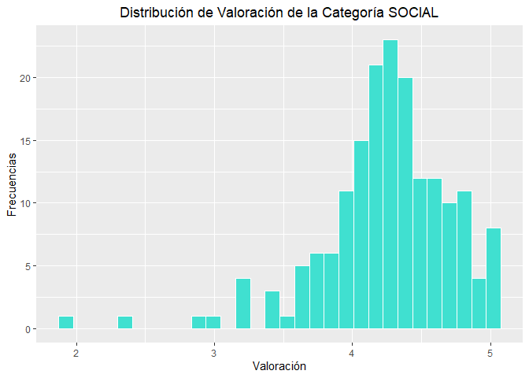

|  | Valor |
| --- | --- |
| Min. | 1.00 |
| 1st Qu. | 5.60 |
| Median | 15.00 |
| Mean | 37.05 |
| 3rd Qu. | 34.00 |
| Max. | 1020.00 |

```r
Analisis_Categoria <- function(categoria) {
  datos <- data %>%
    dplyr::filter(`Categoría` == categoria)

  g1 <- ggplot(data = datos, aes(x = `Valoración`)) +
  geom_histogram(bins = 30, color = "white", fill = "turquoise") +
  xlab("Valoración") + ylab("Frecuencias") +
  ggtitle(paste("Distribución de Valoración de la Categoría", categoria)) +
  theme(plot.title = element_text(hjust = 0.5))

  tabla <- as.data.frame(round(as.matrix(summary(data$`Tamaño(M)`)), 2))
  names(tabla) <- "Valor"
  print(g1)
  return(tabla)
}

knitr::kable(Analisis_Categoria("SOCIAL"))
```

> La distribución de la valoración para nivel Social tiene forma asimétrica negativa. Es decir, los datos se concentran en valores altos de valoración

### Pregunta 5

Sólo hay 2 apps que indican explícitamente “Sólo adultos”. No obstante, en los nombres de las aplicaciones se encuentra varias veces la palabra “adult” o “Adult”. Genere un buscador que reciba cierta palabra y retorne una tabla (en porcentaje) de la `CLASIFICACIÓN` de dichas apps que contenga esa palabra. Pruebe su buscador con la palabra “adult” y comente los resultados.

```r
buscador_palabra <- function(palabra) {
  indice <- grep(palabra, data$App)
  tabla <- data %>%
    dplyr::slice(indice) %>%
    dplyr::count(Clasificacion2) %>%
    dplyr::rename(Clasificacion = Clasificacion2,
                  Numero = n)
  return(tabla)
}

knitr::kable(buscador_palabra("adult"))
```

| Clasificacion | Numero |
| --- | --- |
| Mayores de 17 años | 1 |

### Pregunta 6

Calcule el promedio y desviación estándar de la variable `VALORACIÓN. Si se utiliza el supuesto de normalidad, simule 9000 datos de una distribución normal cuyos parámetros sean justamente los calculados de los datos reales y realice ambos gráficos. ¿Se parece la simulación a los datos reales? Concluya. (Utilice la función rnorm() para generar muestras con distribución normal).

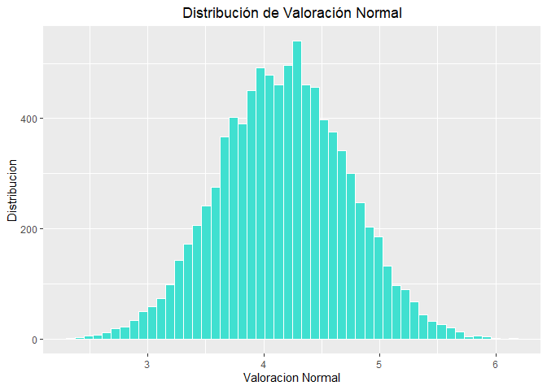

```r
promedio <- mean(data$Valoración, na.rm = TRUE)
desviacion <- sd(data$Valoración, na.rm = TRUE)

datos <- data.frame(Simulacion = rnorm(9000, promedio, desviacion))
ggplot(data = datos, aes(x = Simulacion)) +
  geom_histogram(bins = 50, color = "white", fill = "turquoise") +
  xlab("Valoracion Normal") + ylab("Distribucion") +
  ggtitle("Distribución de Valoración Normal") +
  theme(plot.title = element_text(hjust = 0.5))
```

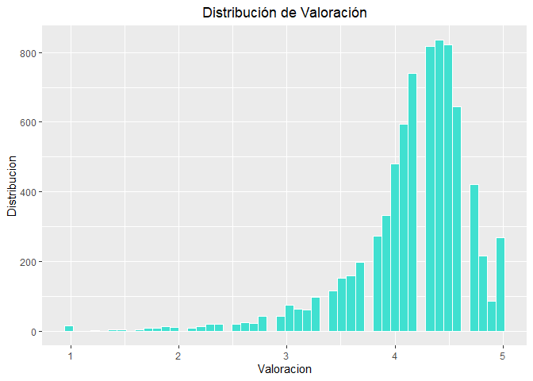

```r
ggplot(data = data, aes(x = `Valoración`)) +
  geom_histogram(bins = 50, color = "white", fill = "turquoise") +
  xlab("Valoracion") + ylab("Distribucion") +
  ggtitle("Distribución de Valoración") +
  theme(plot.title = element_text(hjust = 0.5))
```

> La distribución de la valoración no se parece a la de la distribución normal. La distribución de la variable valoración no es simétrica y se concentra en valores altos de valoración.